# MLR

Assumptions: 1) Linearity: The expected (mean) outcome is a linear function of the predictors. Also, the parameters must be linear. 2) Homoscedasticity: The residuals, conditional on X, have constant variance. 3) Independence: Errors do not covary after conditioning on X. 4) Normality: Errors follow a normal distribution. 5) No multicollinearity: Independent variables cannot be predicted from each other. 6) No outlier effects: The model represents the data well, and no observations disproportionately influence the model fit. 7) No measurement error: Predictors are measured perfectly. 8) No specification error: The statistical model matches the data generating process in its functional form and in which variables are included.

```r
plot(model2, which=1) #This plot shows our model follows a linear path, shown in red line
```

[output not shown]

```r
plot(model2, which=2) #this plot shows our model does not follow a normal distribution as it passes 1 on the X axis it becomes exponential
```

[output not shown]

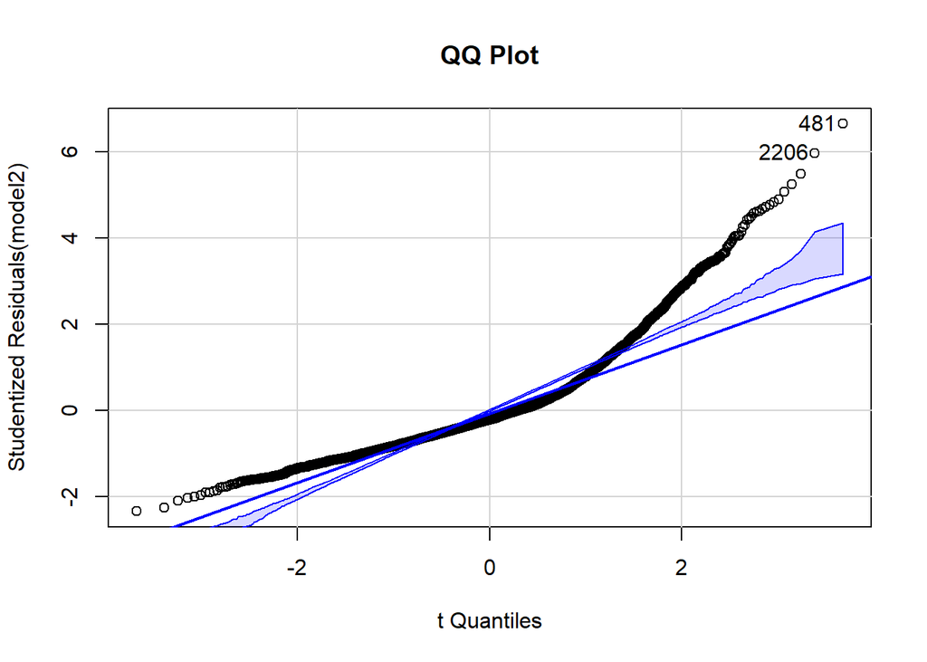

```
## [1]  481 2206
```

```r
#However, the central limit theorem tells us that with a sufficiently large enough sample size a normal distribution is expected. Here our sample size is 4000 observations

qqPlot(model2, main="QQ Plot") #better diagram
```

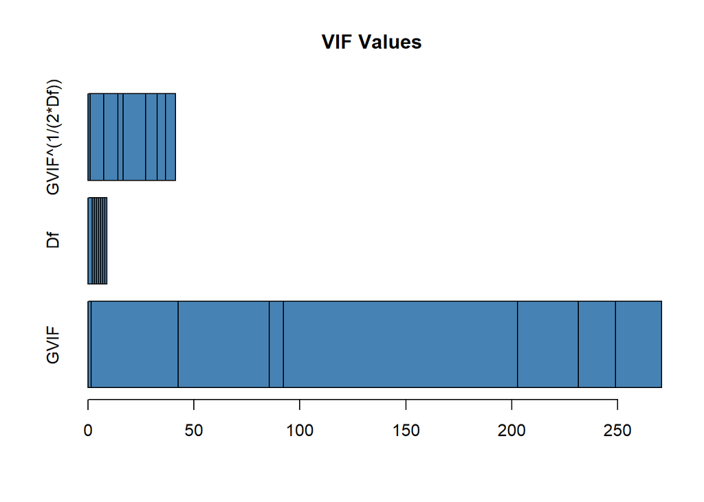

```r
#usingVIF
vif <- vif(model)
barplot(vif, main = "VIF Values", horiz = TRUE, col = "steelblue")
```

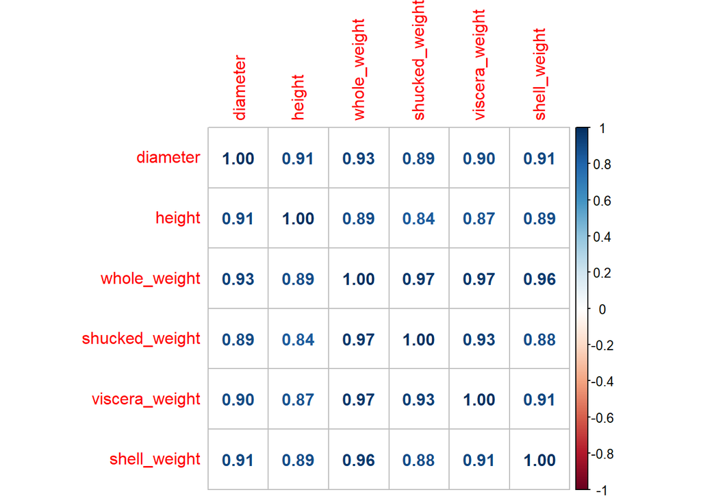

```r
#using corrpolot
dataset = df[3:8] #sex, length, and rings are not included

corrplot(cor(dataset), method = "number")
```

```r
model_performance(model2) #lower R2, but is linear
```

```
## # Indices of model performance
##
## AIC       |      AICc |       BIC |    R2 | R2 (adj.) |  RMSE | Sigma
## ---------------------------------------------------------------------
## 19571.924 | 19571.951 | 19616.279 | 0.389 |     0.388 | 2.520 | 2.522
```

```r
model_performance(model1) #higher R2 but is non linear
```

```
## # Indices of model performance
##
## AIC       |      AICc |       BIC |    R2 | R2 (adj.) |  RMSE | Sigma
## ---------------------------------------------------------------------
## 18358.399 | 18358.452 | 18421.763 | 0.544 |     0.543 | 2.178 | 2.180
```

```r
#Although we have a higher R2 in model1 as compared to model2, we are unable to satisfy linearity assumption, therefore we are unable to proceed with this model
```

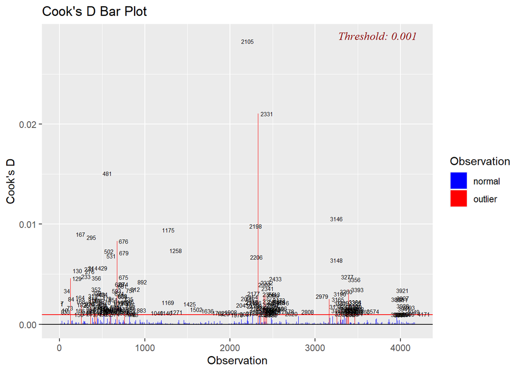

```r
ols_plot_cooksd_bar(model2)
```

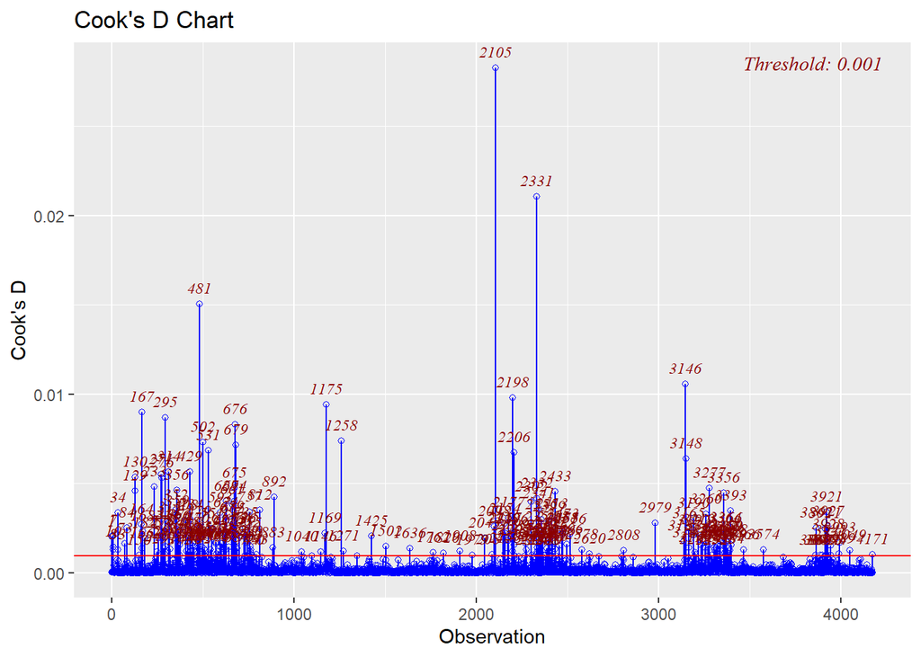

```r
ols_plot_cooksd_chart(model2)
```

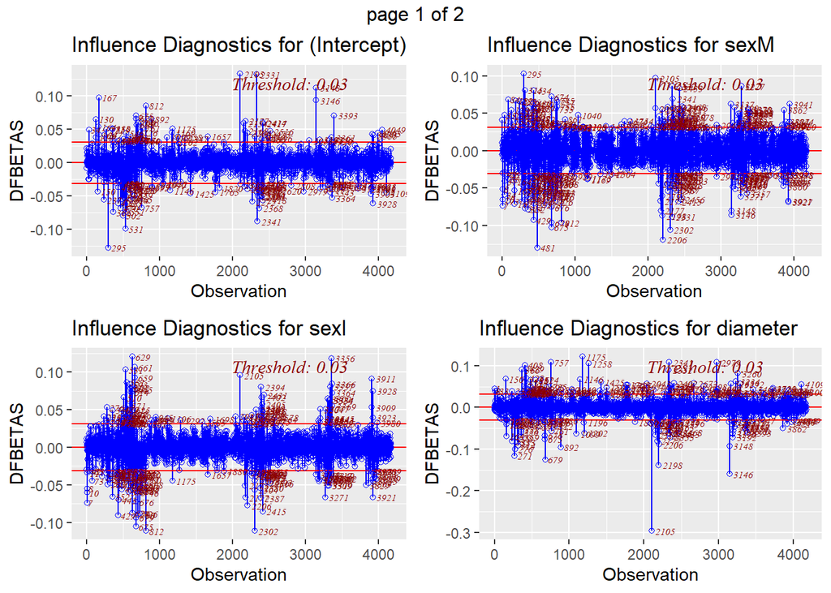

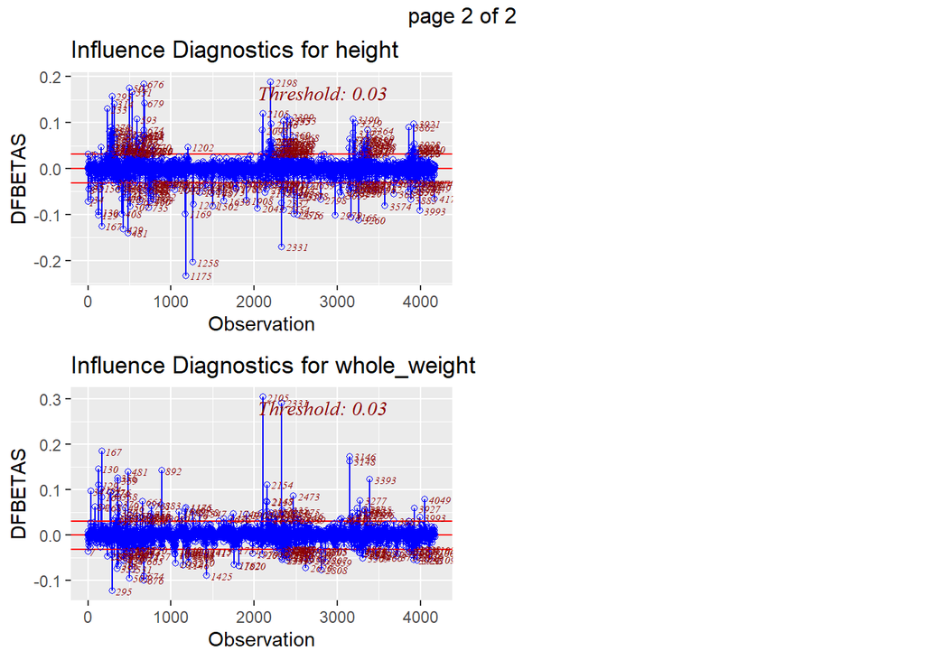

```r
ols_plot_dfbetas(model2)
```

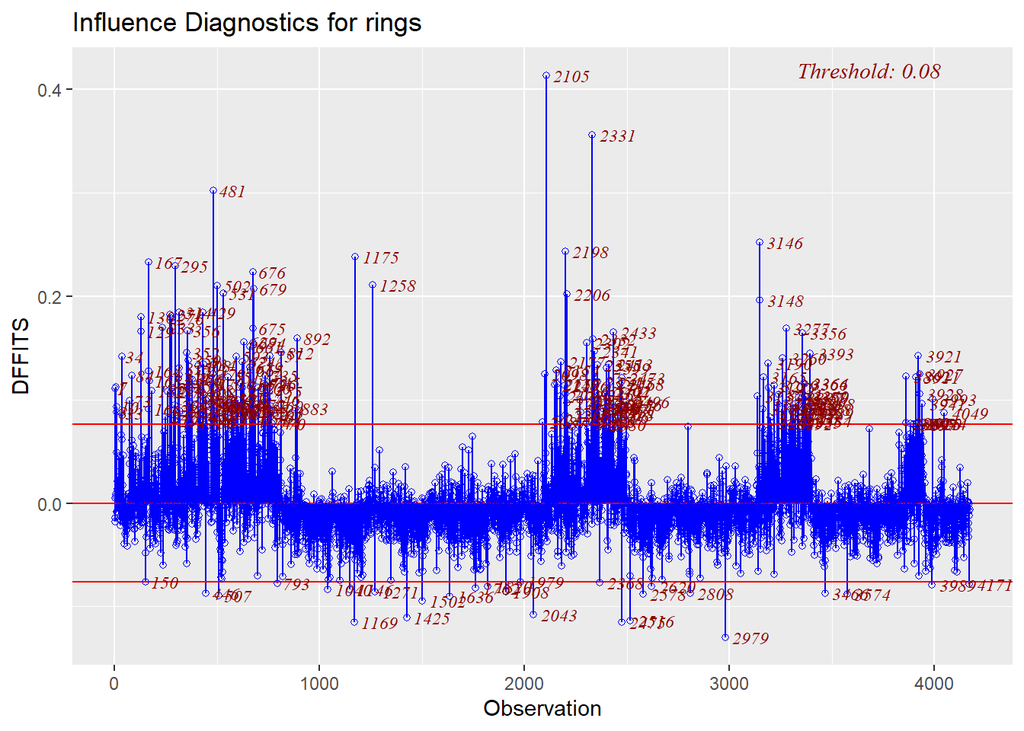

```r
ols_plot_dffits(model2)
```

```r
#Here we can identify outliers that can skew our regression
outlierTest(model2)
```

```
##      rstudent unadjusted p-value Bonferroni p
## 481  6.655547         3.1892e-11   1.3309e-07
## 2206 5.981074         2.4027e-09   1.0027e-05
## 2105 5.495898         4.1196e-08   1.7191e-04
## 295  5.256519         1.5416e-07   6.4331e-04
## 2302 5.081546         3.9078e-07   1.6307e-03
## 675  4.902984         9.7987e-07   4.0890e-03
## 2332 4.836396         1.3699e-06   5.7165e-03
## 2433 4.765958         1.9437e-06   8.1109e-03
## 3277 4.730736         2.3112e-06   9.6445e-03
## 679  4.676089         3.0165e-06   1.2588e-02
```

```r
#check normality
check_normality(model2)
```

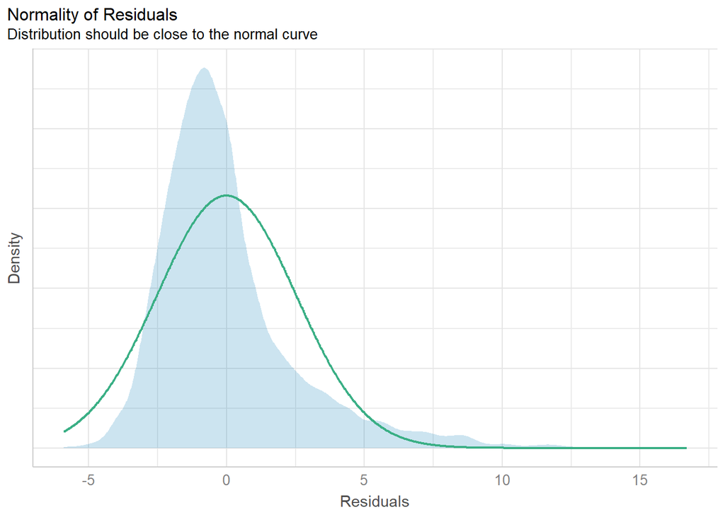

```r
plot(check_normality(model2))
```

```r
#Due to the Central Limit Theorem we can ignore as our observations are sufficiently large enough (4000 obs)
```

```r
#Anova test
anova(model1, model2)
```

```
## Analysis of Variance Table
##
## Model 1: rings ~ sex + diameter + height + whole_weight + shucked_weight +
##     viscera_weight + shell_weight
## Model 2: rings ~ sex + diameter + height + whole_weight
##   Res.Df   RSS Df Sum of Sq      F    Pr(>F)
## 1   4164 19792
## 2   4167 26510 -3     -6718 471.12 < 2.2e-16 ***
## ---
## Signif. codes:  0 '***' 0.001 '**' 0.01 '*' 0.05 '.' 0.1 ' ' 1
```

```r
car::ncvTest(model2)
```

```
## Non-constant Variance Score Test
## Variance formula: ~ fitted.values
## Chisquare = 431.059, Df = 1, p = < 2.22e-16
```

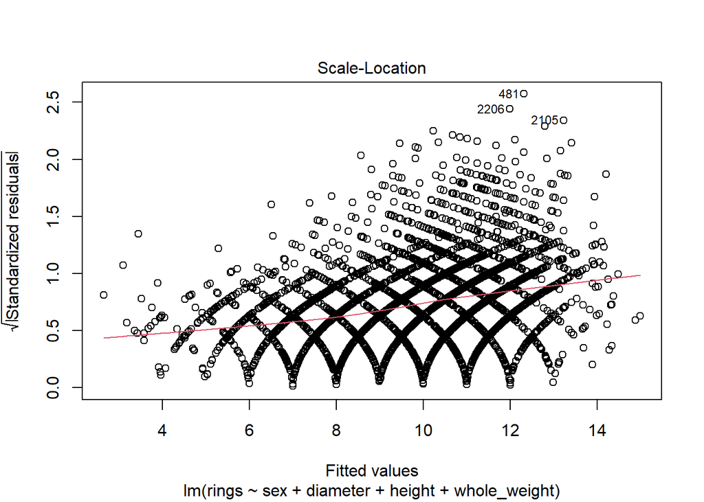

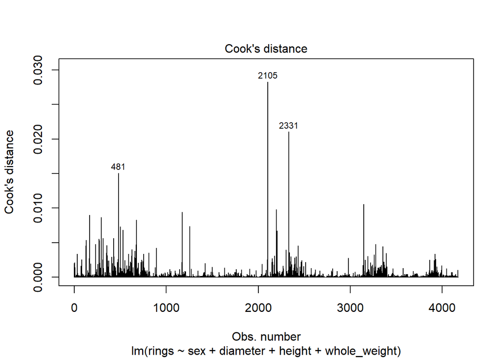

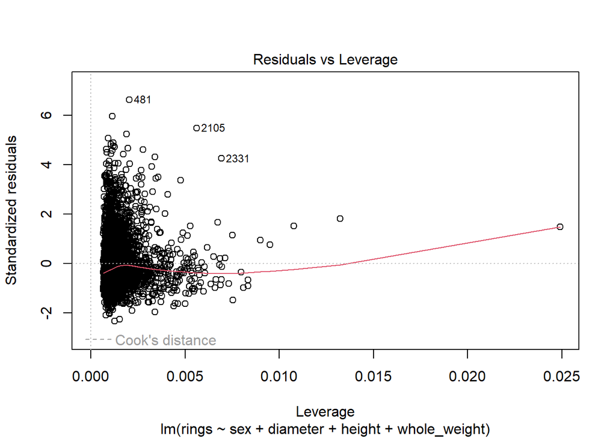

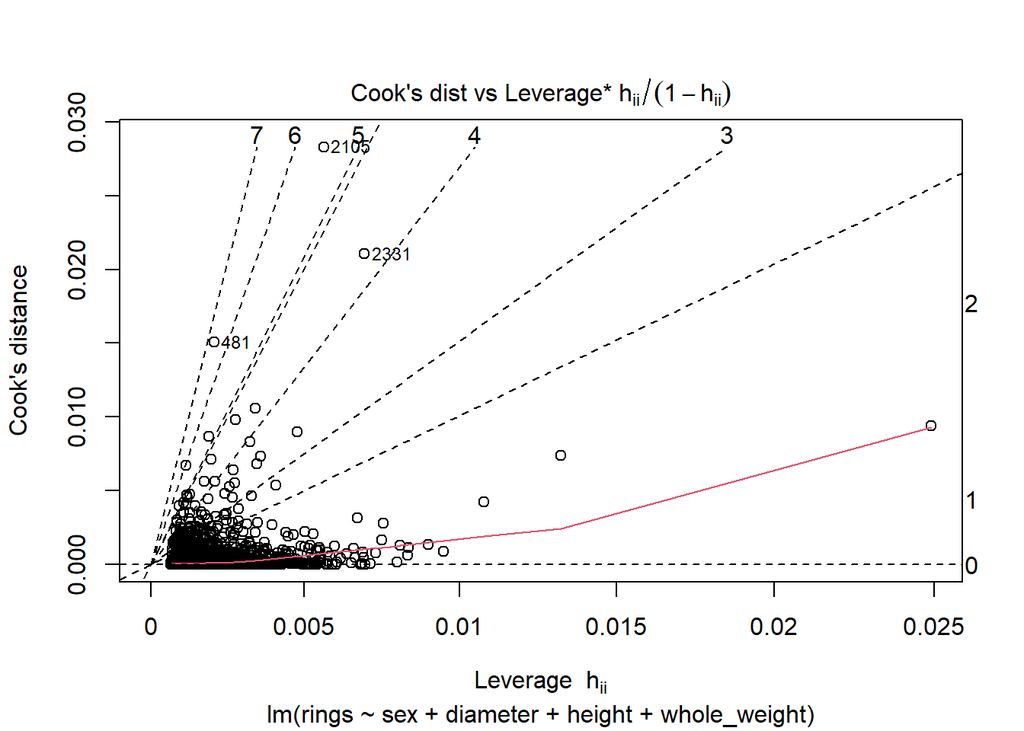

```r
plot(model2, which=1:6)
```

```r
summary(model2)
```

```
##
## Call:
## lm(formula = rings ~ sex + diameter + height + whole_weight,
##     data = df)
##
## Residuals:
##     Min      1Q  Median      3Q     Max
## -5.8946 -1.5822 -0.5387  0.8674 16.6835
##
## Coefficients:
##              Estimate Std. Error t value Pr(>|t|)
## (Intercept)   2.94916    0.31598   9.333  < 2e-16 ***
## sexI         -1.02576    0.11677  -8.784  < 2e-16 ***
## sexM         -0.13205    0.09547  -1.383    0.167
## diameter      5.65874    1.19353   4.741 2.20e-06 ***
## height       41.88769    2.53861  16.500  < 2e-16 ***
## whole_weight -0.93626    0.22193  -4.219 2.51e-05 ***
## ---
## Signif. codes:  0 '***' 0.001 '**' 0.01 '*' 0.05 '.' 0.1 ' ' 1
##
## Residual standard error: 2.522 on 4167 degrees of freedom
## Multiple R-squared:  0.3891, Adjusted R-squared:  0.3884
## F-statistic: 530.9 on 5 and 4167 DF,  p-value: < 2.2e-16
```

IV Appendix

```r
(modcompare <- ols_step_all_possible(model))
```

```
##     Index N
## 8       1 1
## 4       2 1
## 3       3 1
## 2       4 1
## 5       5 1
## 7       6 1
## 1       7 1
## 6       8 1
## 35      9 2
## 31     10 2
## 33     11 2
## 36     12 2
## 15     13 2
## 30     14 2
```

[output cut: 753 more lines]

```r
view(modcompare)
```

```r
(modcompare1 <- ols_step_best_subset(model))
```

```
##                                      Best Subsets Regression
## -------------------------------------------------------------------------------------------------
## Model Index    Predictors
## -------------------------------------------------------------------------------------------------
##      1         shell_weight
##      2         shucked_weight shell_weight
##      3         height shucked_weight shell_weight
##      4         sex height shucked_weight shell_weight
##      5         sex height whole_weight shucked_weight viscera_weight
##      6         sex diameter height whole_weight shucked_weight viscera_weight
##      7         sex diameter height whole_weight shucked_weight viscera_weight shell_weight
##      8         sex length diameter height whole_weight shucked_weight viscera_weight shell_weight
## -------------------------------------------------------------------------------------------------
##
##                                                         Subsets Regression Summary
## -------------------------------------------------------------------------------------------------------------------------------------------
##                        Adj.        Pred
## Model    R-Square    R-Square    R-Square      C(p)          AIC          SBIC          SBC           MSEP        FPE       HSP       APC
## -------------------------------------------------------------------------------------------------------------------------------------------
##   1        0.3942      0.3941      0.3935    1361.3696    19529.1882    7685.6250    19548.1974    26303.2220    6.3062    0.0015    0.6064
##   2        0.4746      0.4744      0.4735     629.1384    18936.7712    7093.4969    18962.1168    22816.5857    5.4716    0.0013    0.5261
##   3        0.5093      0.5090       0.508     314.5475    18653.8010    6810.7832    18685.4830    21315.5864    5.1129    0.0012    0.4916
##   4        0.5213      0.5207      0.5195     207.0656    18554.5442    6709.6282    18598.8990    20799.6154    4.9915    0.0012    0.4798
##   5        0.5305      0.5298      0.5283     125.0538    18475.5397    6630.7608    18526.2309    20404.6524    4.8979    0.0012    0.4708
##   6        0.5386      0.5378      0.5362      52.9873    18404.7965    6560.2058    18461.8240    20056.8576    4.8156    0.0012    0.4629
##   7        0.5439      0.5431      0.5411       6.4198    18358.3990    6513.9748    18421.7629    19830.3474    4.7623    0.0011    0.4578
##   8        0.5440      0.5430      0.5409       8.0000    18359.9782    6515.5604    18429.6785    19833.1111    4.7641    0.0011    0.4580
## -------------------------------------------------------------------------------------------------------------------------------------------
## AIC: Akaike Information Criteria
##  SBIC: Sawa's Bayesian Information Criteria
##  SBC: Schwarz Bayesian Criteria
##  MSEP: Estimated error of prediction, assuming multivariate normality
##  FPE: Final Prediction Error
##  HSP: Hocking's Sp
##  APC: Amemiya Prediction Criteria
```

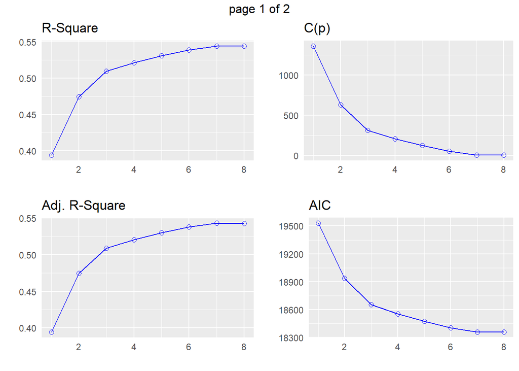

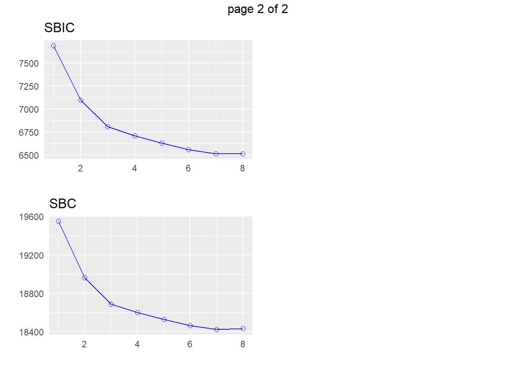

```r
plot(modcompare1)
```